# Homework 1

Alex Osterbuhr

## Section 1

Using the following data, produce a visualization with patient_days_admitted on the x-axis and dollar_spent_per_patient on the y-axis. After producing this visualization, explain what this relationship means and how this relationship might guide a decision.

After looking at the bivariate relationship in the previous visualization, add department to the visualization as a grouping variable. Does this change your interpretation of the relationship or add any expanded understanding? If so, how? Does this visualization offer any additional explanatory power over the more simple visualization? Explain.

### Q 1

The more time spent admitted, the more money spent as well.

### Q 2

Cancer and Cardiac patients spend much more than General admitted patients. Cancer seems to be the most expensive reason to be admitted, but Cardiac increases slighlty more over time relative to the others.

```r
library(ggplot2)
library(dplyr)
library(sjPlot)
sec_1 <- read.csv("https://www.nd.edu/~sberry5/data/visualizationData.csv")
q_1 <- glm(dollar_spent_per_patient ~ patient_days_admitted,
              data = sec_1,
              family = gaussian)
summary(q_1)
```

```
##
## Call:
## glm(formula = dollar_spent_per_patient ~ patient_days_admitted,
##     family = gaussian, data = sec_1)
##
## Deviance Residuals:
##    Min      1Q  Median      3Q     Max
## -641.4  -326.2  -114.4   237.7  1349.3
##
## Coefficients:
##                       Estimate Std. Error t value Pr(>|t|)
## (Intercept)           1143.613     80.504  14.206  < 2e-16 ***
## patient_days_admitted   23.956      4.521   5.298  5.1e-07 ***
## ---
## Signif. codes:  0 '***' 0.001 '**' 0.01 '*' 0.05 '.' 0.1 ' ' 1
##
## (Dispersion parameter for gaussian family taken to be 197072.1)
##
##     Null deviance: 30166159  on 126  degrees of freedom
## Residual deviance: 24634019  on 125  degrees of freedom
## AIC: 1912.7
##
## Number of Fisher Scoring iterations: 2
```

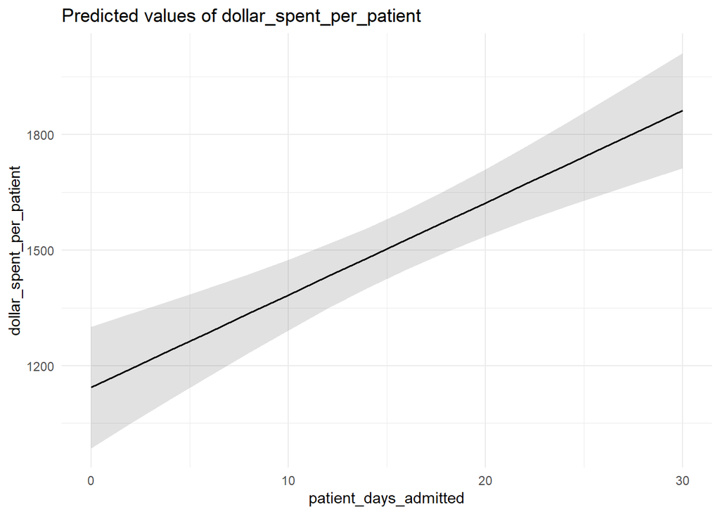

```r
sjPlot::plot_model(q_1,
                   "pred",
                   terms = "patient_days_admitted") +
  ggplot2::theme_minimal()
```

```r
q_2 <-  glm(dollar_spent_per_patient ~ patient_days_admitted * department,
              data = sec_1,
              family = gaussian)
summary(q_2)
```

```
##
## Call:
## glm(formula = dollar_spent_per_patient ~ patient_days_admitted *
##     department, family = gaussian, data = sec_1)
##
## Deviance Residuals:
##    Min      1Q  Median      3Q     Max
## -443.5  -150.7    -5.5   139.4   628.1
##
## Coefficients:
##                                          Estimate Std. Error t value Pr(>|t|)
## (Intercept)                              1941.060     87.633  22.150  < 2e-16
## patient_days_admitted                      23.191      5.190   4.469 1.78e-05
## departmentcardiac                        -679.840    147.230  -4.618 9.76e-06
## departmentgeneral                       -1050.388     99.773 -10.528  < 2e-16
## patient_days_admitted:departmentcardiac     4.790      8.003   0.598    0.551
## patient_days_admitted:departmentgeneral     1.202      5.856   0.205    0.838
##
## (Intercept)                             ***
## patient_days_admitted                   ***
## departmentcardiac                       ***
## departmentgeneral                       ***
## patient_days_admitted:departmentcardiac
## patient_days_admitted:departmentgeneral
## ---
## Signif. codes:  0 '***' 0.001 '**' 0.01 '*' 0.05 '.' 0.1 ' ' 1
##
## (Dispersion parameter for gaussian family taken to be 47379.79)
##
##     Null deviance: 30166159  on 126  degrees of freedom
## Residual deviance:  5732954  on 121  degrees of freedom
## AIC: 1735.5
##
## Number of Fisher Scoring iterations: 2
```

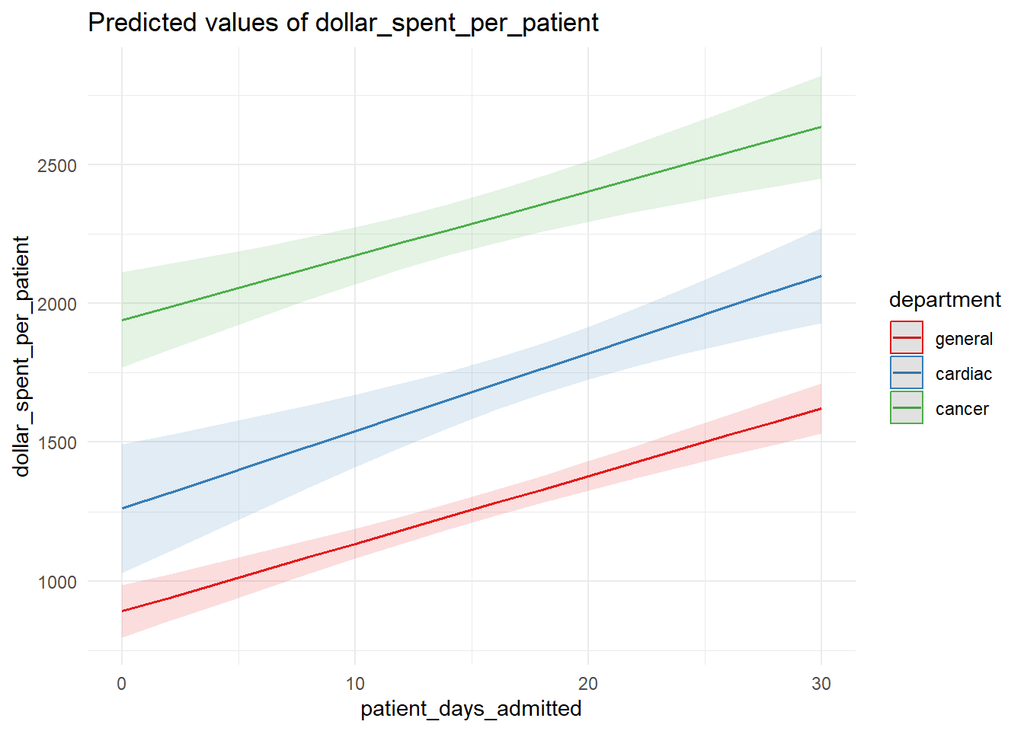

```r
sjPlot::plot_model(q_2,
                   "pred",
                   terms = c("patient_days_admitted", "department")) +
  ggplot2::theme_minimal()
```

## Section 2

Using the following data, formulate a hypothesis for training.sessions.attended.year’s effect on customer.satisfaction.scores.year. Please clearly state the relationship that you would expect to find. Using an appropriate technique from the general linear model, test your hypothesis and report your findings – interpretation of your model’s coefficients is critical. Describe your rationale for any data processing that you might undertake.

After reporting and interpreting your findings, offer some insight as to how you could use these findings.

```r
sec_2 <- read.csv("https://www.nd.edu/~sberry5/data/glmData.csv")
library(betareg)
sec_2$bisatisfaction <- sec_2$customer.satisfaction.scores.year / 100
sec_2$bisatisfaction <- ifelse(sec_2$bisatisfaction == 1, .999,
                               sec_2$bisatisfaction)

h_test <- betareg(bisatisfaction~training.sessions.attended.year,
                data = sec_2)
summary(h_test)
```

```
##
## Call:
## betareg(formula = bisatisfaction ~ training.sessions.attended.year, data = sec_2)
##
## Standardized weighted residuals 2:
##     Min      1Q  Median      3Q     Max
## -1.8909 -0.6744 -0.2670  0.2827  7.5505
##
## Coefficients (mean model with logit link):
##                                 Estimate Std. Error z value Pr(>|z|)
## (Intercept)                     0.393434   0.052708   7.464 8.37e-14 ***
## training.sessions.attended.year 0.146184   0.008377  17.450  < 2e-16 ***
##
## Phi coefficients (precision model with identity link):
##       Estimate Std. Error z value Pr(>|z|)
## (phi)   9.9428     0.6014   16.53   <2e-16 ***
## ---
## Signif. codes:  0 '***' 0.001 '**' 0.01 '*' 0.05 '.' 0.1 ' ' 1
##
## Type of estimator: ML (maximum likelihood)
## Log-likelihood: 413.1 on 3 Df
## Pseudo R-squared: 0.2341
## Number of iterations: 14 (BFGS) + 1 (Fisher scoring)
```

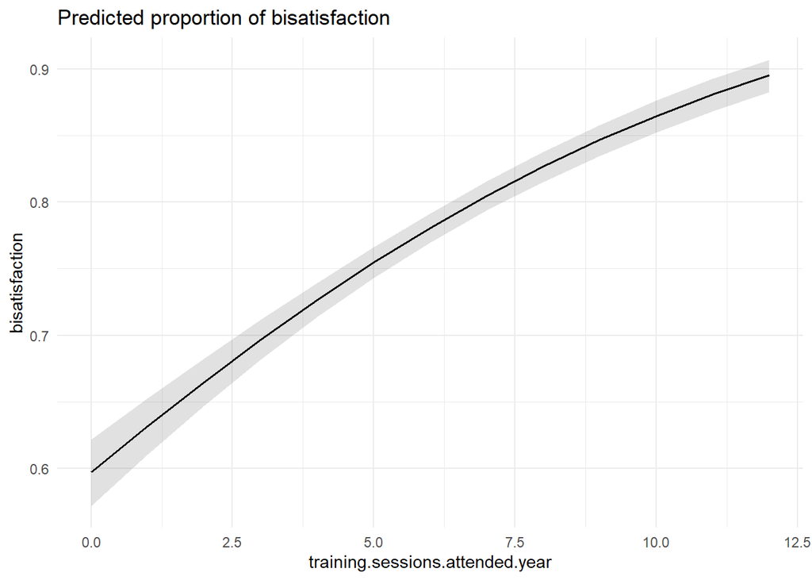

```r
sjPlot::plot_model(h_test,
                   "pred",
                   terms = "training.sessions.attended.year")+
  ggplot2::theme_minimal()
```

## Section 3

Using the following data, determine what variables influence a franchise’s ultimate outcome – failure or success. Using any variables available to you, select the appropriate method and test your model. Discuss your results and describe your rationale for any data processing that you might undertake.

### Description of Process

First I ensured that I could track Open/Closed as a binomial. I then created a glm against the rest of the data except for storeId. This returned an error that read algorithm did not converge, which told me that one of the variables allows for perfect association. I found it to be dailyNetProfitThousands. In that plot we can see that any store with a profit of under about 5.5 is closed, and any store with a profit of over about 7.4 is open. There seemed to be no data for anything between those two ranges. After running the glm without that variable again, I saw there is significance with vartiables peoplePerSqMile and employeeCount. Plotting those two showed that peoplePerSqMile fit a bit better. You cannot plot this way with the profit variable. Seems that the model (minus profit variable) has a low AIC at 72.19 and the Pr(>|z|) are essentially zero for the two plotted variables. The model is a good predictor.

```r
sec_3 <- read.csv("https://www.nd.edu/~sberry5/data/outcomeData.csv")
summary(sec_3)
```

```
##     storeID      outcomeClosedOpen employeeCount    dailyNetProfitThousands
##  Min.   :  1.0   Min.   :0.0000    Min.   : 3.623   Min.   : 2.495
##  1st Qu.:119.5   1st Qu.:0.0000    1st Qu.: 9.502   1st Qu.: 3.967
##  Median :238.0   Median :0.0000    Median :12.347   Median : 4.650
##  Mean   :238.0   Mean   :0.4758    Mean   :12.325   Mean   : 6.348
##  3rd Qu.:356.5   3rd Qu.:1.0000    3rd Qu.:15.028   3rd Qu.: 8.944
##  Max.   :475.0   Max.   :1.0000    Max.   :22.114   Max.   :10.298
##  quartersWithHealthViolations peoplePerSqMile
##  Min.   :0.0000               Min.   : 63.91
##  1st Qu.:0.0000               1st Qu.:195.15
##  Median :0.0000               Median :240.73
##  Mean   :0.5874               Mean   :244.51
##  3rd Qu.:1.0000               3rd Qu.:295.11
##  Max.   :3.0000               Max.   :393.97
```

```r
sec_3$outcomeClosedOpen = as.integer(sec_3$outcomeClosedOpen)
success <- glm(outcomeClosedOpen ~ employeeCount + quartersWithHealthViolations
               + peoplePerSqMile + dailyNetProfitThousands,
               data = sec_3,
               family = binomial(link = 'logit'))
summary(success)
```

```
##
## Call:
## glm(formula = outcomeClosedOpen ~ employeeCount + quartersWithHealthViolations +
##     peoplePerSqMile + dailyNetProfitThousands, family = binomial(link = "logit"),
##     data = sec_3)
##
## Deviance Residuals:
##        Min          1Q      Median          3Q         Max
## -5.937e-05  -2.100e-08  -2.100e-08   2.100e-08   4.177e-05
##
## Coefficients:
##                                Estimate Std. Error z value Pr(>|z|)
## (Intercept)                  -1.262e+02  9.850e+04  -0.001    0.999
## employeeCount                 1.948e-01  8.316e+03   0.000    1.000
## quartersWithHealthViolations  3.456e+00  1.170e+04   0.000    1.000
## peoplePerSqMile               8.778e-02  2.716e+02   0.000    1.000
## dailyNetProfitThousands       1.530e+01  1.360e+04   0.001    0.999
##
## (Dispersion parameter for binomial family taken to be 1)
##
##     Null deviance: 6.5738e+02  on 474  degrees of freedom
## Residual deviance: 8.3344e-09  on 470  degrees of freedom
## AIC: 10
##
## Number of Fisher Scoring iterations: 25
```

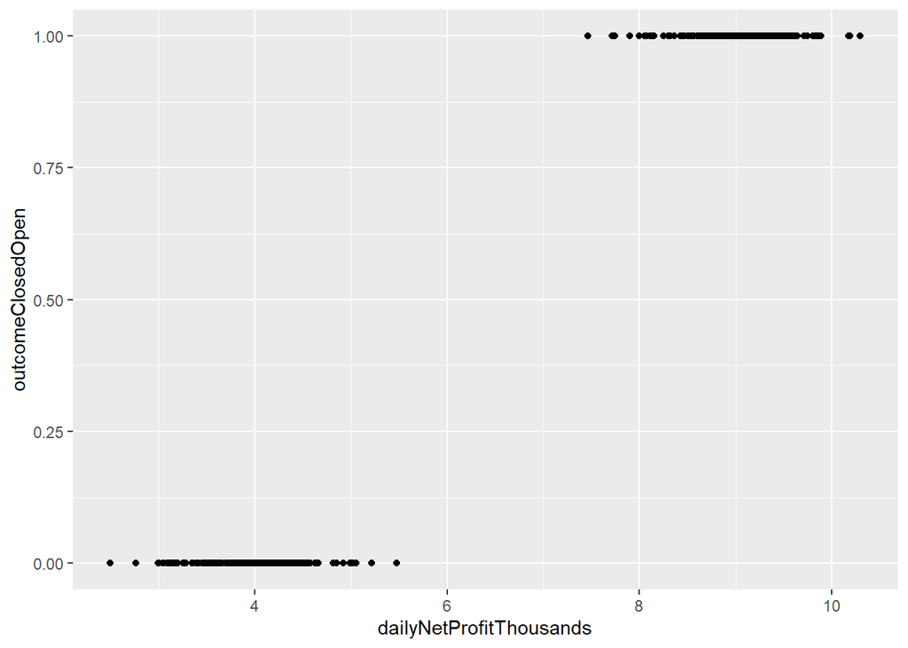

```r
ggplot(aes(dailyNetProfitThousands, outcomeClosedOpen), data = sec_3) +
  geom_point()
```

```r
success <- glm(outcomeClosedOpen ~ employeeCount + quartersWithHealthViolations
               + peoplePerSqMile,
               data = sec_3,
               family = binomial(link = 'logit'))
summary(success)
```

```
##
## Call:
## glm(formula = outcomeClosedOpen ~ employeeCount + quartersWithHealthViolations +
##     peoplePerSqMile, family = binomial(link = "logit"), data = sec_3)
##
## Deviance Residuals:
##      Min        1Q    Median        3Q       Max
## -2.58521  -0.01893  -0.00037   0.03030   3.12312
##
## Coefficients:
##                               Estimate Std. Error z value Pr(>|z|)
## (Intercept)                  -42.96939    7.37622  -5.825 5.70e-09 ***
## employeeCount                  0.99582    0.21288   4.678 2.90e-06 ***
## quartersWithHealthViolations   0.17653    0.49261   0.358     0.72
## peoplePerSqMile                0.12058    0.01968   6.126 8.99e-10 ***
## ---
## Signif. codes:  0 '***' 0.001 '**' 0.01 '*' 0.05 '.' 0.1 ' ' 1
##
## (Dispersion parameter for binomial family taken to be 1)
##
##     Null deviance: 657.38  on 474  degrees of freedom
## Residual deviance:  64.19  on 471  degrees of freedom
## AIC: 72.19
##
## Number of Fisher Scoring iterations: 9
```

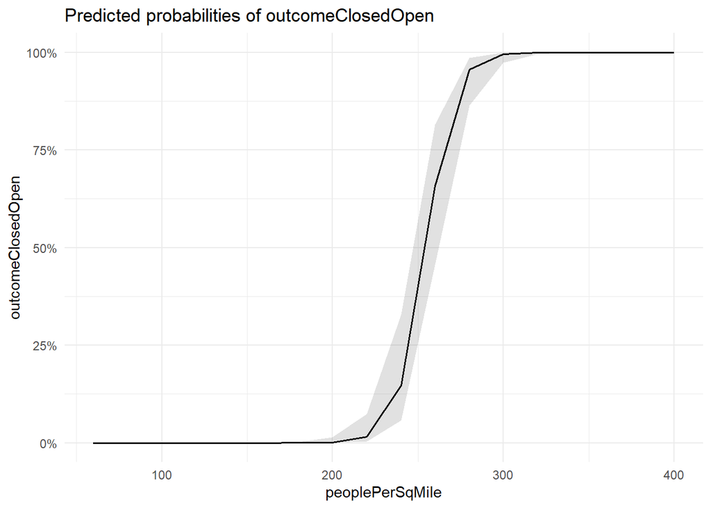

```r
sjPlot::plot_model(success, 'pred', terms = 'peoplePerSqMile') +
 ggplot2::theme_minimal()
```

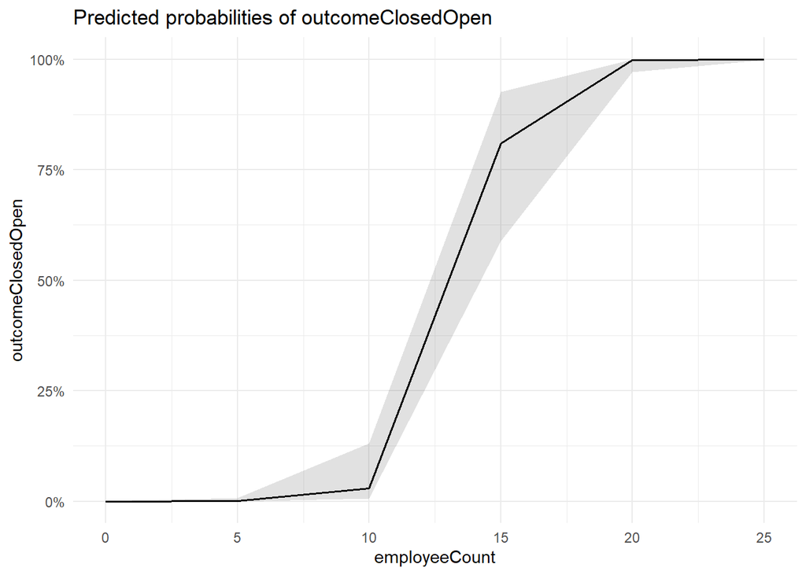

```r
sjPlot::plot_model(success, 'pred', terms = 'employeeCount') +
 ggplot2::theme_minimal()
```

## Section 4

Using the modeldata package, select any data and create any model. You need to explain why you chose your data and model, and discuss your results. If you find yourself struggling to find one. the pd_speech is a great model for logistic regression and has plenty of data.

### Summary

I chose to use the crickets data set. There are only three variables here. We have a categorical variable called species with only two different species. Then we have rate and temp. By looking quickly at the data, we could see that rate and temp most likely would increase together. After creating a basic linear model and plotting this data, we see that we would fail to reject that hypothesis. There is significance between rate of chirps per minute and temperature. One species, the O.exclamationis, is much more noisy than the O.niveus. Unfortunately there is data for the O.niveus at temps around 20.5 and under but not the other species. On the other side there is data for the O.exclamationis at temps 28.5 and up but not for the O.niveus. This would need to be researched further as it could potentially mean they live in different climates or they cannot handle one species cannot handle cold and one cannot handle warm.

```r
library(modeldata)
sec_4 <- modeldata::crickets
str(sec_4)
```

```
## tibble [31 × 3] (S3: tbl_df/tbl/data.frame)
##  $ species: Factor w/ 2 levels "O. exclamationis",..: 1 1 1 1 1 1 1 1 1 1 ...
##  $ temp   : num [1:31] 20.8 20.8 24 24 24 24 26.2 26.2 26.2 26.2 ...
##  $ rate   : num [1:31] 67.9 65.1 77.3 78.7 79.4 80.4 85.8 86.6 87.5 89.1 ...
```

```r
crickets <- lm(temp ~ rate, data = sec_4)
summary(crickets)
```

```
##
## Call:
## lm(formula = temp ~ rate, data = sec_4)
##
## Residuals:
##     Min      1Q  Median      3Q     Max
## -1.8833 -0.7744 -0.2928  0.6355  2.2744
##
## Coefficients:
##             Estimate Std. Error t value Pr(>|t|)
## (Intercept)  7.96242    0.88811   8.966  7.4e-10 ***
## rate         0.21680    0.01188  18.251  < 2e-16 ***
## ---
## Signif. codes:  0 '***' 0.001 '**' 0.01 '*' 0.05 '.' 0.1 ' ' 1
##
## Residual standard error: 1.1 on 29 degrees of freedom
## Multiple R-squared:  0.9199, Adjusted R-squared:  0.9171
## F-statistic: 333.1 on 1 and 29 DF,  p-value: < 2.2e-16
```

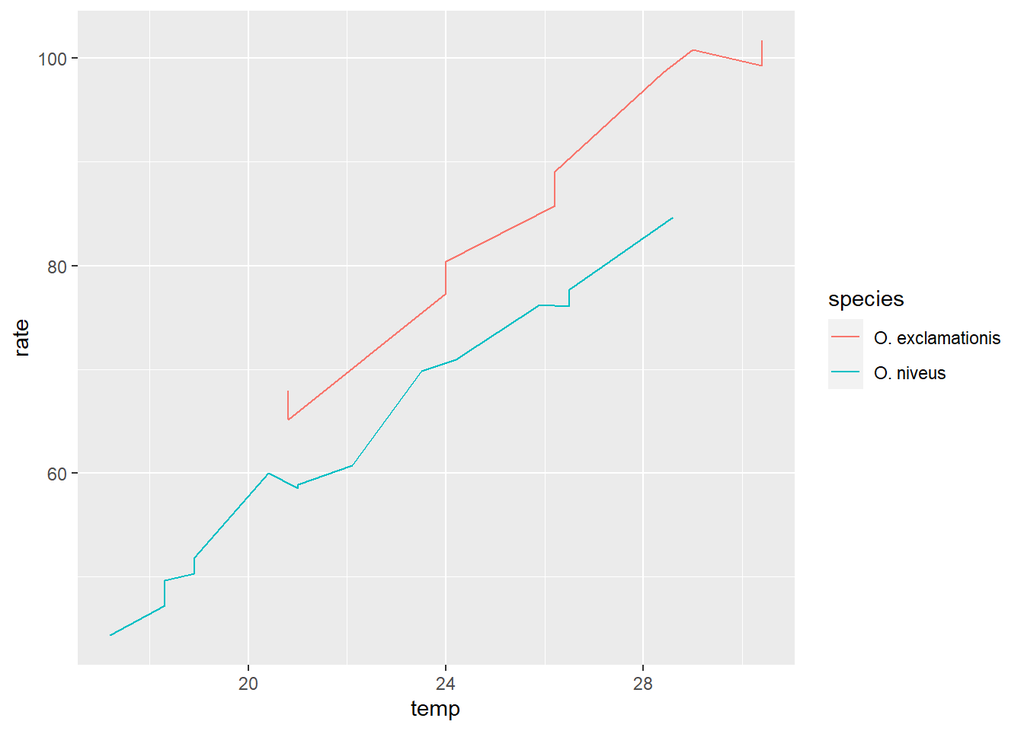

```r
ggplot()+
  geom_line(aes(x= temp,y= rate, color = species), data= sec_4)
```